# Übung

InfoVis1

In dieser Übung geht es darum, die Grafiken aus dem Blog-post Kovic (2014) zu rekonstruieren. Schau dir die Grafiken in dem Blogpost durch. Freundlicherweise wurden im Blogbeitrag die `ggplot2` Standardeinstellungen benutzt, was die Rekonstruktion relativ einfach macht. Die Links im Text verweisen auf die Originalgrafik, die eingebetteten Plots sind meine eigenen Rekonstruktionen.

Importiere als erstes den Datensatz [initiative_masseneinwanderung_kanton.csv](https://github.com/ResearchMethods-ZHAW/datasets/raw/main/infovis/tagi_data_kantone.csv) (dieser ist auch auf der Blog-Seite verfügbar).

## Aufgabe 1

Rekonstruiere [Grafik 1](https://blog.tagesanzeiger.ch/datenblog/wp-content/uploads/sites/32/2014/03/Kantone-2.png) (Kovic 2014). Erstelle dazu einen Scatterplot wo der Ausländeranteil der Kantone dem Ja-Anteil gegenüber gestellt wird. Speichere den Plot einer Variabel `plot1`.

- nutze `ggplot(kanton, aes(auslanderanteil, ja_anteil))` um den ggplot zu initiieren. Füge danach ein einen Punkte Layer hinzu (`geom_point()`)
- nutze `coord_fixed()` um die beiden Achsen in ein fixes Verhältnis zu setzen (1:1).
- Optional:
  - setze die Achsen Start- und Endwerte mittels `lims()` oder `scale_y_continuous` bzw. `scale_x_continuous`.
  - Setze analog Kovic (2014) die `breaks` (`0.0`, `0.1`…`0.7`) manuell

Rekonstruktion:

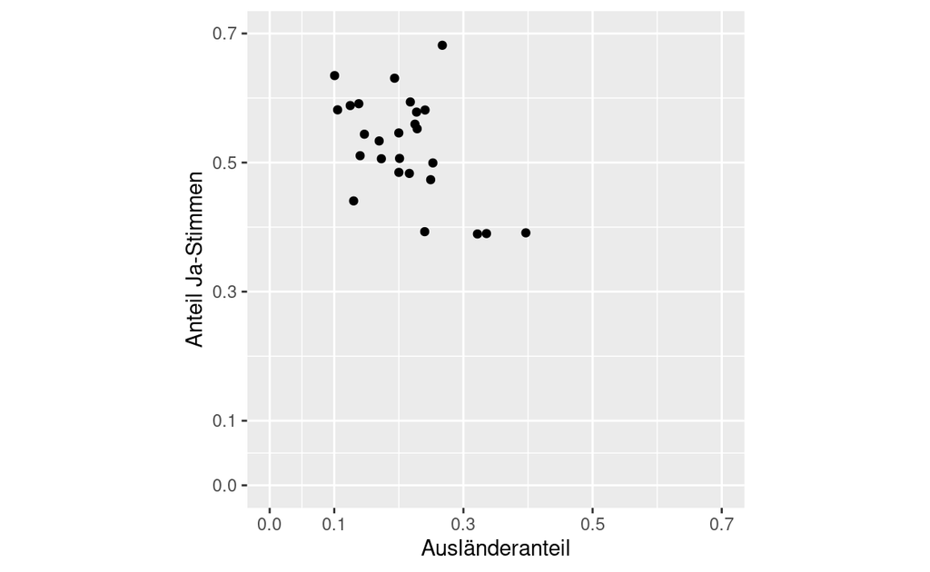

## Aufgabe 2

Rekonstruiere [Grafik 2](https://blog.tagesanzeiger.ch/datenblog/wp-content/uploads/sites/32/2014/03/Kantone-LOESS-986x923.png). Erweitere dazu `plot1` mit einer Trendlinie.

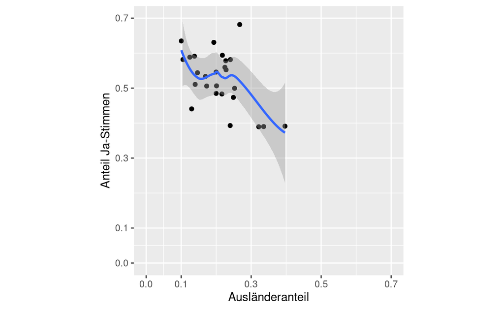

## Aufgabe 3

Importiere die Gemeindedaten [initiative_masseneinwanderung_gemeinde.csv](https://github.com/ResearchMethods-ZHAW/datasets/raw/main/infovis/tagi_data_gemeinden.csv). Rekonstruiere danach [Grafik 3](https://blog.tagesanzeiger.ch/datenblog/wp-content/uploads/sites/32/2014/03/Gemeinden-2-986x939.png) indem du den Ausländeranteil aller Gemeinden dem Ja-Stimmen-Anteil gegenüber. Speichere den Plot als `plot2`

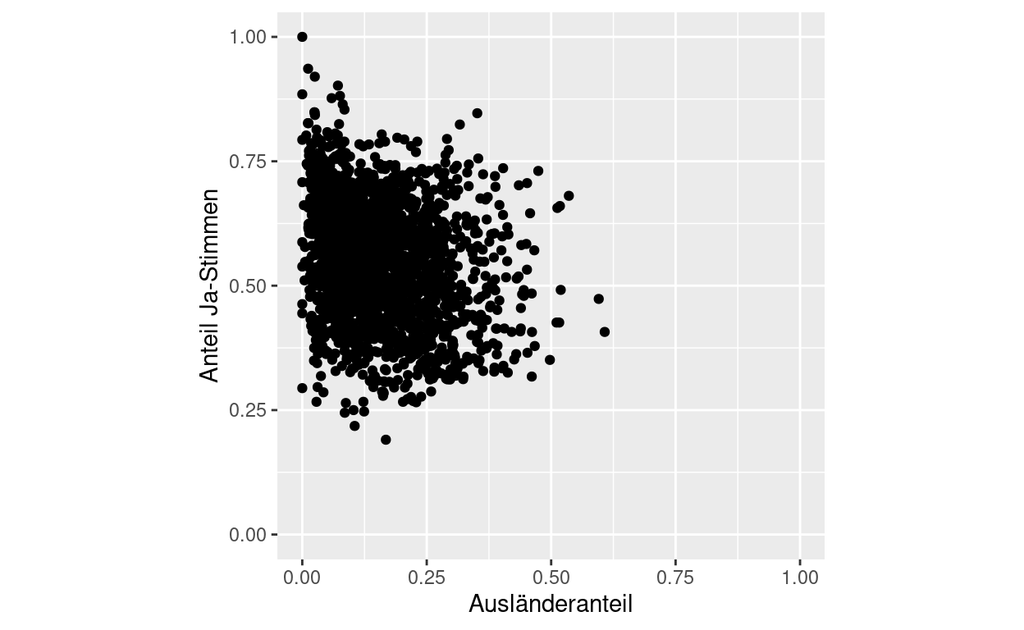

## Aufgabe 4

Rekonstruiere [Grafik 4](https://blog.tagesanzeiger.ch/datenblog/wp-content/uploads/sites/32/2014/03/Gemeinden-GAM-2-986x939.png) indem `plot2` mit einer Trendlinie erweitert wird.

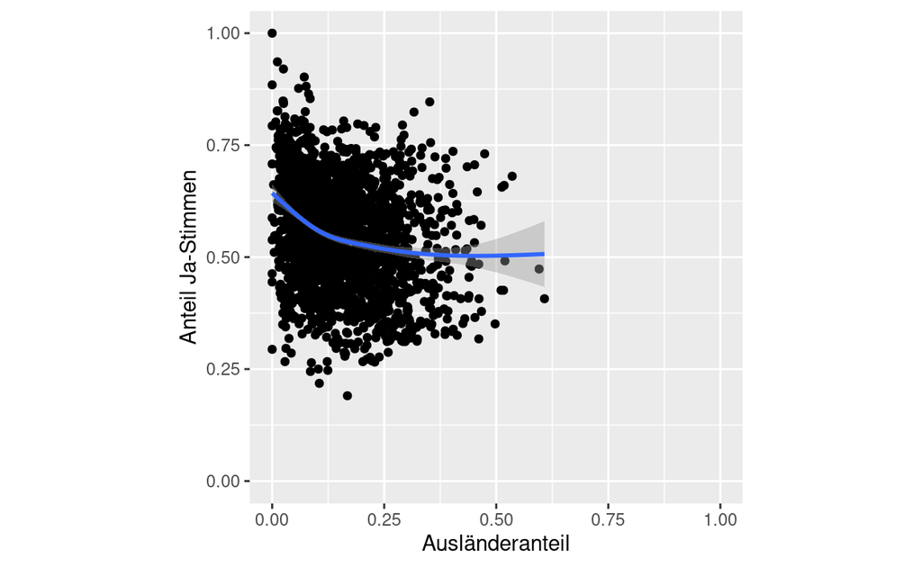

## Aufgabe 5

Rekonstruiere [Grafik 5](https://blog.tagesanzeiger.ch/datenblog/wp-content/uploads/sites/32/2014/03/Gemeinden-x-Kantone-2-986x857.png) indem `plot2` mit `facetting` erweitert wird. Die Facets sollen die einzelnen Kantone sein. Speichere den Plot als `plot3`.

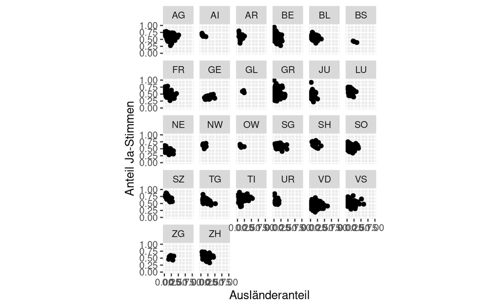

## Aufgabe 6

Rekonstruiere [Grafik 6](https://blog.tagesanzeiger.ch/datenblog/wp-content/uploads/sites/32/2014/03/Gemeinden-x-Kantone-LOESS-2-986x857.png) indem `plot3` mit einer Trendlinie erweitert wird.

Rekonstruktion:

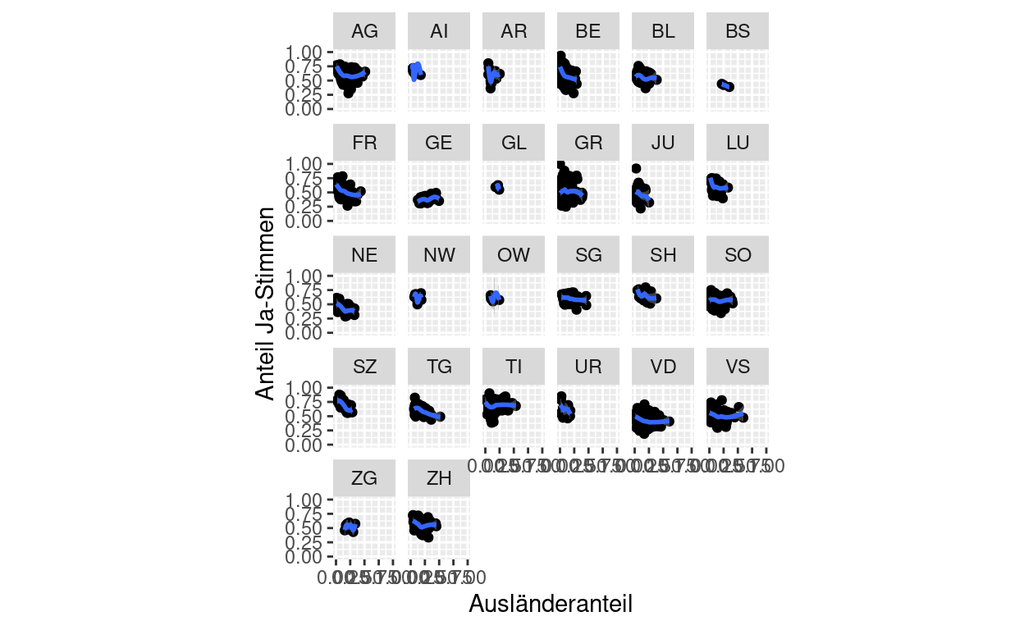

## Aufgabe 7

Rekonstruiere [Grafik 7](https://blog.tagesanzeiger.ch/datenblog/wp-content/uploads/sites/32/2014/03/Gemeinden-x-Quantile-2-986x637.png) indem `plot2`mit `facetting` erweitert wird. Die Facets sollen nun den Grössen-Quantilen entsprechen. Speichere den Plot unter `plot4`.

Rekonstruktion:

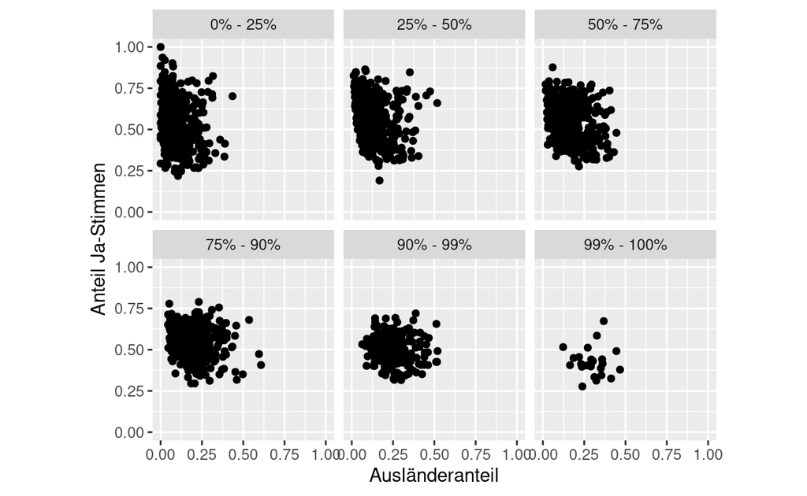

## Aufgabe 8

Rekonstruiere [Grafik 8](https://blog.tagesanzeiger.ch/datenblog/wp-content/uploads/sites/32/2014/03/Gemeinden-x-Quantile-LOESS-2-986x637.png) indem `plot4` mit einer Trendlinie ausgestattet wird.

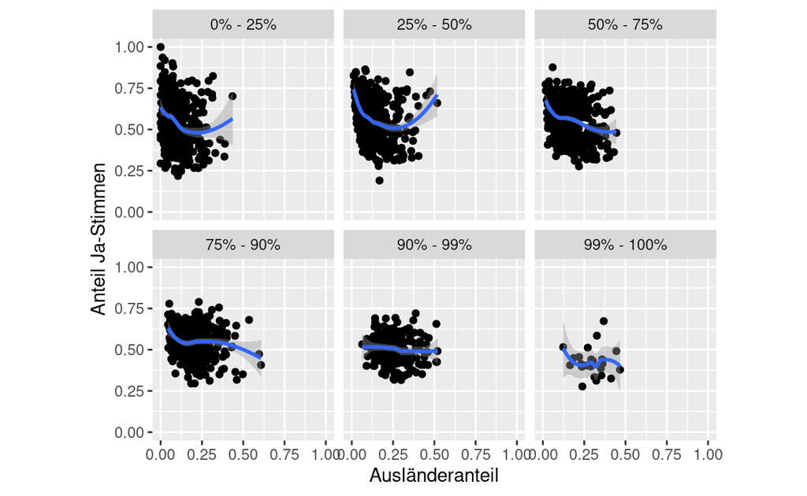

## Aufgabe 9 (Optional, fortgeschritten)

Rekonstruiere die [Korrelationstabelle](https://tagi_dwpro.s3.amazonaws.com/UMvkt/2/fs.html).

Tipp: - Nutze `group_by()` und `summarise()` - Nutze `cor.test()` um den Korrelationskoeffizienten sowie den p-Wert zu erhalten. - Mit `$estimate` und `$p.value` können die entsprechenden Werte direkt angesprochen werden

Hinweis: aus bisher unerklärlichen Gründen weiche gewisse meiner Werte leicht von den Berechnungen aus Kovic (2014) ab.

| kanton | Korr.Koeffizient | Signifikanz |
| --- | --- | --- |
| AG | -0.2362552 | *** |
| AI | -0.7828022 | - |
| AR | -0.0892817 | - |
| BE | -0.4422003 | *** |
| BL | -0.2919712 | ** |
| BS | -0.9935385 | - |
| FR | -0.4217634 | *** |
| GE | 0.3753004 | * |
| GL | -0.4070120 | - |
| GR | -0.0426607 | - |
| JU | -0.2252540 | - |
| LU | -0.3048455 | ** |
| NE | -0.5214180 | *** |
| NW | -0.2018174 | - |
| OW | -0.4813090 | - |
| SG | -0.2449093 | * |
| SH | -0.2995527 | - |
| SO | -0.0533442 | - |
| SZ | -0.7259276 | *** |
| TG | -0.5522862 | *** |
| TI | 0.1512509 | - |
| UR | -0.3848167 | - |
| VD | -0.2685301 | *** |
| VS | -0.1736954 | * |
| ZG | 0.0407166 | - |
| ZH | -0.2744683 | *** |

Kovic, Marko. 2014. “Je Weniger Ausländer, Desto Mehr Ja-Stimmen? Wirklich?” *Tagesanzeiger Datenblog*. https://blog.tagesanzeiger.ch/datenblog/index.php/668/je-weniger-auslaender-desto-mehr-ja-stimmen-wirklich.